# STAT636: Unsupervised Imputation

How to deal with missing values

# Loading packages

```r
if(!require(tidyverse)){install.packages('tidyverse');require(tidyverse)}
```

# Summary

Missing data is incredibly common in practice. Hence, we need a variety of practical ways to deal with missingness so we can choose an appropriate method for a given situation.

Note that missingness generally just references the features. If the supervisor is missing, then that observation is in need of prediction not imputation.

# Running example: Simulation

```r
set.seed(1)
X_c         = matrix(rnorm(12),nrow=6) %*% matrix(c(1,.75,.75,1),nrow=2)
X           = X_c
X[c(1,2),1] = NA

Y           = rnorm(nrow(X))

X_c
```

```
##            [,1]        [,2]
## [1,] -0.2608820  0.01758869
## [2,]  0.7373869  0.87605720
## [3,] -0.4037926 -0.05094011
## [4,]  1.3662395  0.89107221
## [5,]  1.4633436  1.75891200
## [6,] -0.5280860 -0.22550805
```

```r
X
```

```
##            [,1]        [,2]
## [1,]         NA  0.01758869
## [2,]         NA  0.87605720
## [3,] -0.4037926 -0.05094011
## [4,]  1.3662395  0.89107221
## [5,]  1.4633436  1.75891200
## [6,] -0.5280860 -0.22550805
```

# Listwise deletion

This is the default of most statistical computing packages/functions

All it means is we ignore observations with missing data

For example, if we wanted to do a regression:

```r
(summary(lm(Y~X)))
```

```
##
## Call:
## lm(formula = Y ~ X)
##
## Residuals:
##         3         4         5         6
##  0.123906  0.008149 -0.015485 -0.116570
##
## Coefficients:
##             Estimate Std. Error t value Pr(>|t|)
## (Intercept)   0.7384     0.1165   6.337   0.0996 .
## X1           -0.6674     0.2568  -2.598   0.2339
## X2            0.1350     0.3041   0.444   0.7339
## ---
## Signif. codes:  0 '***' 0.001 '**' 0.01 '*' 0.05 '.' 0.1 ' ' 1
##
## Residual standard error: 0.171 on 1 degrees of freedom
##   (2 observations deleted due to missingness)
## Multiple R-squared:  0.9746, Adjusted R-squared:  0.9238
## F-statistic: 19.18 on 2 and 1 DF,  p-value: 0.1594
```

As 1/3 of the values in the first feature is missing, we can instead remove that feature and just regress on the second:

```r
(summary(lm(Y~X[,2])))
```

```
##
## Call:
## lm(formula = Y ~ X[, 2])
##
## Residuals:
##       1       2       3       4       5       6
## -0.8139 -1.8686  0.8893  0.3106  0.8840  0.5986
##
## Coefficients:
##             Estimate Std. Error t value Pr(>|t|)
## (Intercept)   0.2037     0.6434   0.317    0.767
## X[, 2]       -0.6276     0.7262  -0.864    0.436
##
## Residual standard error: 1.243 on 4 degrees of freedom
## Multiple R-squared:  0.1573, Adjusted R-squared:  -0.05335
## F-statistic: 0.7468 on 1 and 4 DF,  p-value: 0.4362
```

This works fine as long as

- You have a lot of data
- There isn’t much missing
- The data are ``Missing Completely at Random’’ (MCAR)

Referring to our running example, the missing values in X are created via an MCAR mechanism

Let’s look at what listwise deletion looks like. See here for a tutorial on ggplot.

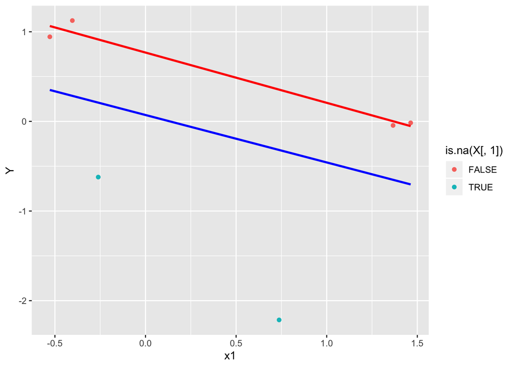

```r
ggplot(data = data.frame('x1' = X_c[,1],'x1NA' = X[,1], 'Y' = Y), aes(x1,Y)) +
  geom_point(mapping = aes(color = is.na(X[,1]))) +
  geom_smooth(method='lm', color='blue', se = FALSE) +
  geom_smooth(mapping = aes(x1NA,Y), method='lm',na.rm = TRUE, color='red', se = FALSE)
```

# Mean/median/mode imputation

The simplest (conceptually and computationally) imputation method

```r
M = is.na(X)
Ximpute  = X
for(j in 1:ncol(X)){
  Ximpute[M[,j],j] = mean(X[,j],na.rm=TRUE)
}
X
```

```
##            [,1]        [,2]
## [1,]         NA  0.01758869
## [2,]         NA  0.87605720
## [3,] -0.4037926 -0.05094011
## [4,]  1.3662395  0.89107221
## [5,]  1.4633436  1.75891200
## [6,] -0.5280860 -0.22550805
```

```r
Ximpute
```

```
##            [,1]        [,2]
## [1,]  0.4744262  0.01758869
## [2,]  0.4744262  0.87605720
## [3,] -0.4037926 -0.05094011
## [4,]  1.3662395  0.89107221
## [5,]  1.4633436  1.75891200
## [6,] -0.5280860 -0.22550805
```

For a qualitative feature, the mode is a common choice

```r
Xqual = c('moo','cluck','cluck','oink',NA)
tbl   = table(Xqual)
(Xqual[is.na(Xqual)] = names(tbl)[which.max(tbl)])
```

```
## [1] "cluck"
```

Note that `mode’ is a built-in function to R that checks the data structure:

```r
mode(Xqual)
```

```
## [1] "character"
```

# Iterative scheme

A common approach is to iteratively treat each feature as the supervisor and predict the missing values.

We need somehow to start this iteration. A good omnibus solution to this is to use mean/median/mode imputation for the 0th iteration. Then, we can iteratively update the missing values in each column of X with any supervised method. We will use linear regression here.

0th iteration:

```r
M = is.na(X)
Ximpute = X
for(j in 1:ncol(X)){
  Ximpute[M[,j],j] = mean(X[,j],na.rm=TRUE)
}
```

Now we can start the iterations. If computations are at a premium, we might only do a couple of iterations. If we aren’t so restricted, we might iterate until convergence

```r
maxIters  = 10
threshold = .01
converged = FALSE
nIters    = 0
while(!converged){
  nIters = nIters + 1
  Ximpute_old = Ximpute
  for(j in 1:ncol(X)){
    fitX_j = lm(Ximpute[,j]~Ximpute[,-j])
    Ximpute[M[,j],j] = fitX_j$fitted[M[,j]]
  }
  print(max(abs(Ximpute_old - Ximpute)/abs(Ximpute_old)))
  if( max(abs(Ximpute_old - Ximpute)/abs(Ximpute_old)) < threshold){
    converged = TRUE
  }
  if( nIters >= maxIters){
    converged  = TRUE
    warning('algorithm failed to converge')
  }
}
```

```
## [1] 1.063294
## [1] 3.260592
## [1] 0.1910347
## [1] 0.04774534
## [1] 0.01480032
## [1] 0.004908254
```

```r
X
```

```
##            [,1]        [,2]
## [1,]         NA  0.01758869
## [2,]         NA  0.87605720
## [3,] -0.4037926 -0.05094011
## [4,]  1.3662395  0.89107221
## [5,]  1.4633436  1.75891200
## [6,] -0.5280860 -0.22550805
```

```r
Ximpute
```

```
##            [,1]        [,2]
## [1,] -0.1628115  0.01758869
## [2,]  0.7877799  0.87605720
## [3,] -0.4037926 -0.05094011
## [4,]  1.3662395  0.89107221
## [5,]  1.4633436  1.75891200
## [6,] -0.5280860 -0.22550805
```

```r
X_c
```

```
##            [,1]        [,2]
## [1,] -0.2608820  0.01758869
## [2,]  0.7373869  0.87605720
## [3,] -0.4037926 -0.05094011
## [4,]  1.3662395  0.89107221
## [5,]  1.4633436  1.75891200
## [6,] -0.5280860 -0.22550805
```

Let’s looks at a linear model fit via …

## list-wise deletion:

```r
(summary(lm(Y~X)))
```

```
##
## Call:
## lm(formula = Y ~ X)
##
## Residuals:
##         3         4         5         6
##  0.123906  0.008149 -0.015485 -0.116570
##
## Coefficients:
##             Estimate Std. Error t value Pr(>|t|)
## (Intercept)   0.7384     0.1165   6.337   0.0996 .
## X1           -0.6674     0.2568  -2.598   0.2339
## X2            0.1350     0.3041   0.444   0.7339
## ---
## Signif. codes:  0 '***' 0.001 '**' 0.01 '*' 0.05 '.' 0.1 ' ' 1
##
## Residual standard error: 0.171 on 1 degrees of freedom
##   (2 observations deleted due to missingness)
## Multiple R-squared:  0.9746, Adjusted R-squared:  0.9238
## F-statistic: 19.18 on 2 and 1 DF,  p-value: 0.1594
```

## iterative imputation

```r
(summary(lm(Y~Ximpute)))
```

```
##
## Call:
## lm(formula = Y ~ Ximpute)
##
## Residuals:
##       1       2       3       4       5       6
## -0.8137 -1.8685  0.7789  0.6869  0.6819  0.5345
##
## Coefficients:
##             Estimate Std. Error t value Pr(>|t|)
## (Intercept)  0.08147    0.82708   0.098    0.928
## Ximpute1    -0.66947    2.12077  -0.316    0.773
## Ximpute2     0.11379    2.48920   0.046    0.966
##
## Residual standard error: 1.412 on 3 degrees of freedom
## Multiple R-squared:  0.1844, Adjusted R-squared:  -0.3593
## F-statistic: 0.3392 on 2 and 3 DF,  p-value: 0.7366
```

## using the complete (but unknown) data

```r
(summary(lm(Y~X_c)))
```

```
##
## Call:
## lm(formula = Y ~ X_c)
##
## Residuals:
##       1       2       3       4       5       6
## -0.8321 -1.8766  0.8531  0.4692  0.8046  0.5818
##
## Coefficients:
##             Estimate Std. Error t value Pr(>|t|)
## (Intercept)   0.1455     0.8697   0.167    0.878
## X_c1         -0.2722     2.1307  -0.128    0.906
## X_c2         -0.3229     2.5274  -0.128    0.906
##
## Residual standard error: 1.432 on 3 degrees of freedom
## Multiple R-squared:  0.1619, Adjusted R-squared:  -0.3969
## F-statistic: 0.2897 on 2 and 3 DF,  p-value: 0.7673
```

# Another example

Let’s look at using the iterative imputation scheme in two cases

- Features are independent
- Features are dependent

In both cases, we will examine an MAR missing data mechanism. Let’s define some functions first:

```r
meanImputeF = function(X){
  Ximpute = X
  M       = is.na(X)
  for(j in 1:ncol(X)){
    Ximpute[M[,j],j] = mean(X[,j],na.rm=TRUE)
  }
  return(list('M' = M, 'Ximpute' = Ximpute))
}

iterativeF = function(X, maxIters = 10, threshold = 0.01, verbose = TRUE){
  meanImpute = meanImputeF(X)
  Ximpute    = meanImpute$Ximpute
  M          = meanImpute$M

  converged = FALSE
  nIters    = 0
  while(!converged){
    nIters = nIters + 1
    Ximpute_old = Ximpute
    for(j in 1:ncol(X)){
      fitX_j           = lm(Ximpute[,j]~Ximpute[,-j])
      Ximpute[M[,j],j] = fitX_j$fitted[M[,j]]
    }
    if(verbose){ print(max(abs(Ximpute_old - Ximpute)/abs(Ximpute_old))) }

    if( max(abs(Ximpute_old - Ximpute)/abs(Ximpute_old)) < threshold){
      converged = TRUE
    }
    if( nIters >= maxIters){
      break
      warning('algorithm failed to converge')
    }
  }
  return(Ximpute)
}
```

## Independent

```r
n           = 100
p           = 2

X_c          = matrix(rnorm(n*p),nrow=n)

X            = X_c
missing      = X_c[,1] > 1
X[missing,2] = NA

Xhat = iterativeF(X)
```

```
## [1] 120.1201
## [1] 0.6376592
## [1] 0.2219731
## [1] 0.1033811
## [1] 0.05332223
## [1] 0.02880975
## [1] 0.01593664
## [1] 0.00892735
```

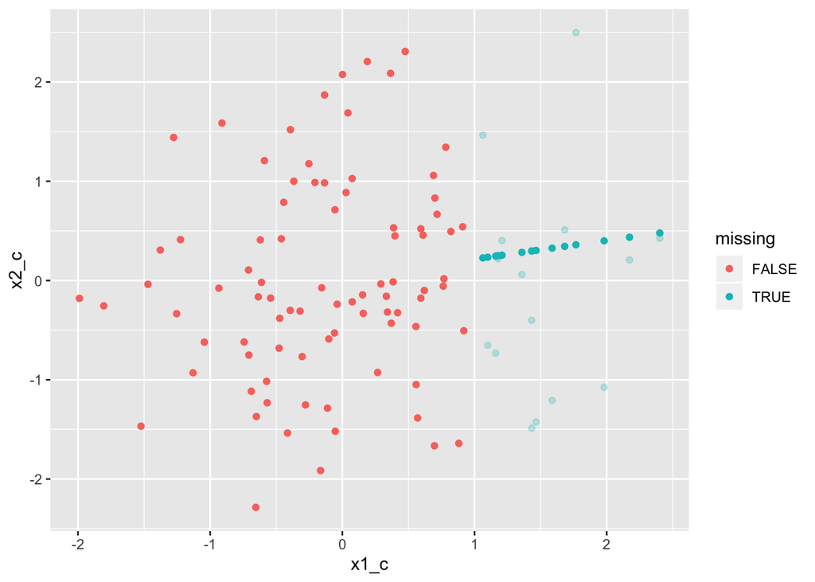

```r
ggplot(data = data.frame('x1_c' = X_c[,1],
                         'x2_c' = X_c[,2],
                         'missing' = missing)) +
  geom_point(mapping = aes(x = x1_c, y = x2_c, color = missing), alpha = .25) +
  geom_point(mapping = aes(x = x1, y = x2, color = missing),
             data = data.frame('x1' = Xhat[,1],
                         'x2' = Xhat[,2],
                         'missing' = missing))
```

## Dependent

Let’s add some dependency to the data set

```r
set.seed(1)
n           = 100
p           = 2

rho         = 0.9
Sigma       = matrix(rho,nrow=p,ncol=p)
diag(Sigma) = 1

X_c          = matrix(rnorm(n*p),nrow=n) %*% chol(Sigma)

X            = X_c
missing      = X_c[,1] > 1
X[missing,2] = NA

Xhat = iterativeF(X)
```

```
## [1] 10.33587
## [1] 0.7870764
## [1] 0.2333604
## [1] 0.1000591
## [1] 0.04810023
## [1] 0.02426893
## [1] 0.01252976
## [1] 0.006543972
```

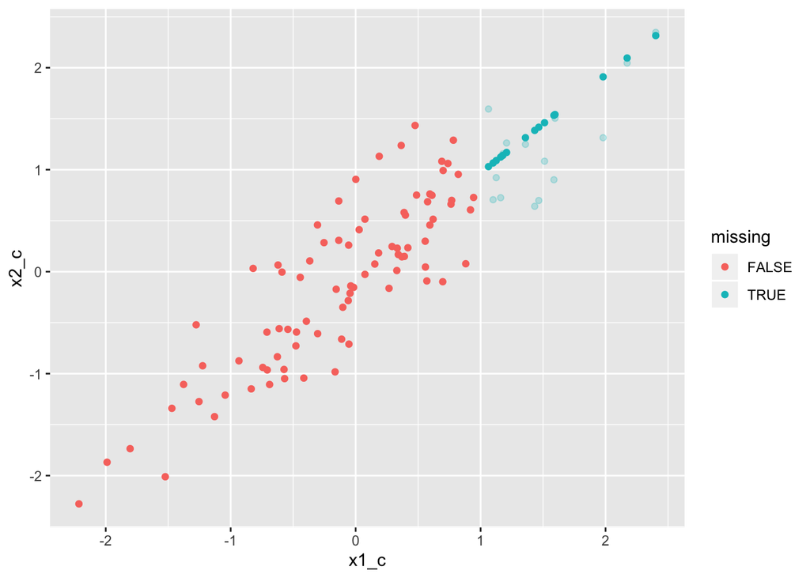

```r
ggplot(data = data.frame('x1_c' = X_c[,1],
                         'x2_c' = X_c[,2],
                         'missing' = missing)) +
  geom_point(mapping = aes(x = x1_c, y = x2_c, color = missing), alpha = .25) +
  geom_point(mapping = aes(x = x1, y = x2, color = missing),
             data = data.frame('x1' = Xhat[,1],
                         'x2' = Xhat[,2],
                         'missing' = missing))
```